# DCP Examples - Semidefinite Programming (SDP)

Biostat/Biomath M257

Author

Dr. Hua Zhou @ UCLA

Published

June 4, 2024

## 1 SDP

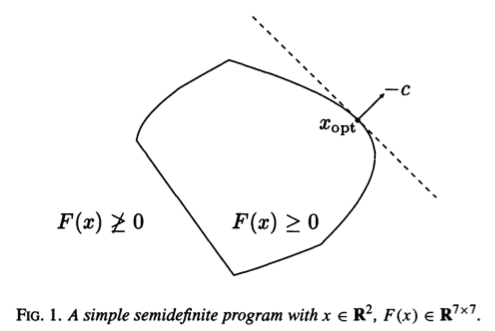

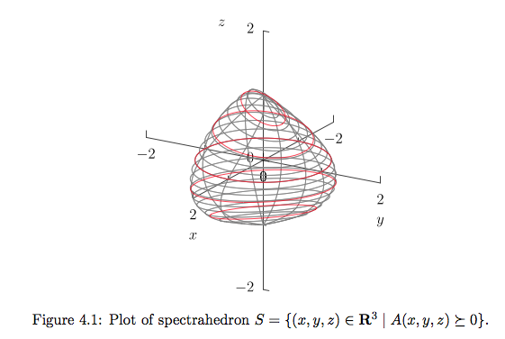

- A **semidefinite program (SDP)** has the form
  $$\begin{eqnarray*}
  &\text{minimize}& \mathbf{c}^T \mathbf{x} \\
  &\text{subject to}& x_1 \mathbf{F}_1 + \cdots + x_n \mathbf{F}_n + \mathbf{G} \preceq \mathbf{0} \quad (\text{LMI, linear matrix inequality}) \\
  & & \mathbf{A} \mathbf{x} = \mathbf{b},
  \end{eqnarray*}$$
  where $\mathbf{G}, \mathbf{F}_1, \ldots, \mathbf{F}_n \in \mathbf{S}^k$, $\mathbf{A} \in \mathbb{R}^{p \times n}$, and $\mathbf{b} \in \mathbb{R}^p$.

  When $\mathbf{G}, \mathbf{F}_1, \ldots, \mathbf{F}_n$ are all diagonal, SDP reduces to LP.
- The **standard form SDP** has form
  $$\begin{eqnarray*}
  &\text{minimize}& \text{tr}(\mathbf{C} \mathbf{X}) \\
  &\text{subject to}& \text{tr}(\mathbf{A}_i \mathbf{X}) = b_i, \quad i = 1, \ldots, p \\
  & & \mathbf{X} \succeq \mathbf{0},
  \end{eqnarray*}$$
  where $\mathbf{C}, \mathbf{A}_1, \ldots, \mathbf{A}_p \in \mathbf{S}^n$.
- An **inequality form SDP** has form
  $$\begin{eqnarray*}
  &\text{minimize}& \mathbf{c}^T \mathbf{x} \\
  &\text{subject to}& x_1 \mathbf{A}_1 + \cdots + x_n \mathbf{A}_n \preceq \mathbf{B},
  \end{eqnarray*}$$
  with variable $\mathbf{x} \in \mathbb{R}^n$, and parameters $\mathbf{B}, \mathbf{A}_1, \ldots, \mathbf{A}_n \in \mathbf{S}^n$, $\mathbf{c} \in \mathbb{R}^n$.
- Exercise. Write LP, QP, QCQP, and SOCP in form of SDP.

## 2 SDP example: nearest correlation matrix

- Let $\mathbb{C}^n$ be the convex set of $n \times n$ correlation matrices
  $$\begin{eqnarray*}
  \mathbb{C}^n = \{ \mathbf{X} \in \mathbf{S}_+^n: x_{ii}=1, i=1,\ldots,n\}.
  \end{eqnarray*}$$
  Given $\mathbf{A} \in \mathbf{S}^n$, often we need to find the closest correlation matrix to $\mathbf{A}$
  $$\begin{eqnarray*}
  &\text{minimize}& \|\mathbf{A} - \mathbf{X}\|_{\text{F}} \\
  &\text{subject to}& \mathbf{X} \in \mathbb{C}^n.
  \end{eqnarray*}$$
  This projection problem can be solved via an SDP
  $$\begin{eqnarray*}
  &\text{minimize}& t \\
  &\text{subject to}& \|\mathbf{A} - \mathbf{X}\|_{\text{F}} \le t \\
  & & \mathbf{X} = \mathbf{X}^T, \, \text{diag}(\mathbf{X}) = \mathbf{1} \\
  & & \mathbf{X} \succeq \mathbf{0}
  \end{eqnarray*}$$
  in variables $\mathbf{X} \in \mathbb{R}^{n \times n}$ and $t \in \mathbb{R}$. The SOC constraint can be written as an LMI
  $$\begin{eqnarray*}
  \begin{pmatrix}
  t \mathbf{I} & \text{vec} (\mathbf{A} - \mathbf{X}) \\
  \text{vec} (\mathbf{A} - \mathbf{X})^T & t
  \end{pmatrix} \succeq \mathbf{0}
  \end{eqnarray*}$$
  by the Schur complement lemma.

## 3 SDP example: eigenvalue problems

- Suppose
  $$\begin{eqnarray*}
  \mathbf{A}(\mathbf{x}) = \mathbf{A}_0 + x_1 \mathbf{A}_1 + \cdots x_n \mathbf{A}_n,
  \end{eqnarray*}$$
  where $\mathbf{A}_i \in \mathbf{S}^m$, $i = 0, \ldots, n$. Let $\lambda_1(\mathbf{x}) \ge \lambda_2(\mathbf{x}) \ge \cdots \ge \lambda_m(\mathbf{x})$ be the ordered eigenvalues of $\mathbf{A}(\mathbf{x})$.
- Minimize the maximal eigenvalue is equivalent to the SDP
  $$\begin{eqnarray*}
  &\text{minimize}& t \\
  &\text{subject to}& \mathbf{A}(\mathbf{x}) \preceq t \mathbf{I}
  \end{eqnarray*}$$
  in variables $\mathbf{x} \in \mathbb{R}^n$ and $t \in \mathbb{R}$.
- Minimizing the sum of $k$ largest eigenvalues is an SDP too. How about minimizing the sum of all eigenvalues?
- Maximize the minimum eigenvalue is an SDP as well.
- Minimize the spread of the eigenvalues $\lambda_1(\mathbf{x}) - \lambda_m(\mathbf{x})$ is equivalent to the SDP
  $$\begin{eqnarray*}
  &\text{minimize}& t_1 - t_m \\
  &\text{subject to}& t_m \mathbf{I} \preceq \mathbf{A}(\mathbf{x}) \preceq t_1 \mathbf{I}
  \end{eqnarray*}$$
  in variables $\mathbf{x} \in \mathbb{R}^n$ and $t_1, t_m \in \mathbb{R}$.
- Minimize the spectral radius (or spectral norm) $\rho(\mathbf{x}) = \max_{i=1,\ldots,m} |\lambda_i(\mathbf{x})|$ is equivalent to the SDP
  $$\begin{eqnarray*}
  &\text{minimize}& t \\
  &\text{subject to}& - t \mathbf{I} \preceq \mathbf{A}(\mathbf{x}) \preceq t \mathbf{I}
  \end{eqnarray*}$$
  in variables $\mathbf{x} \in \mathbb{R}^n$ and $t \in \mathbb{R}$.
- To minimize the condition number $\kappa(\mathbf{x}) = \lambda_1(\mathbf{x}) / \lambda_m(\mathbf{x})$, note $\lambda_1(\mathbf{x}) / \lambda_m(\mathbf{x}) \le t$ if and only if there exists a $\mu > 0$ such that $\mu \mathbf{I} \preceq \mathbf{A}(\mathbf{x}) \preceq \mu t \mathbf{I}$, or equivalently, $\mathbf{I} \preceq \mu^{-1} \mathbf{A}(\mathbf{x}) \preceq t \mathbf{I}$. With change of variables $y_i = x_i / \mu$ and $s = 1/\mu$, we can solve the SDP
  $$\begin{eqnarray*}
  &\text{minimize}& t \\
  &\text{subject to}& \mathbf{I} \preceq s \mathbf{A}_0 + y_1 \mathbf{A}_1 + \cdots y_n \mathbf{A}_n \preceq t \mathbf{I} \\
  & & s \ge 0,
  \end{eqnarray*}$$
  in variables $\mathbf{y} \in \mathbb{R}^n$ and $s, t \ge 0$. In other words, we normalize the spectrum by the smallest eigenvalue and then minimize the largest eigenvalue of the normalized LMI.
- Minimize the $\ell_1$ norm of the eigenvalues $|\lambda_1(\mathbf{x})| + \cdots + |\lambda_m(\mathbf{x})|$ is equivalent to the SDP
  $$\begin{eqnarray*}
  &\text{minimize}& \text{tr} (\mathbf{A}^+) + \text{tr}(\mathbf{A}^-) \\
  &\text{subject to}& \mathbf{A}(\mathbf{x}) = \mathbf{A}^+ - \mathbf{A}^- \\
  & & \mathbf{A}^+ \succeq \mathbf{0}, \mathbf{A}^- \succeq \mathbf{0},
  \end{eqnarray*}$$
  in variables $\mathbf{x} \in \mathbb{R}^n$ and $\mathbf{A}^+, \mathbf{A}^- \in \mathbf{S}_+^n$.
- Roots of determinant. The determinant of a semidefinite matrix $\text{det} (\mathbf{A}(\mathbf{x})) = \prod_{i=1}^m \lambda_i (\mathbf{x})$ is neither convex or concave, but rational powers of the determinant can be modeled using linear matrix inequalities. For a rational power $0 \le q \le 1/m$, the function $\text{det} (\mathbf{A}(\mathbf{x}))^q$ is concave and we have
  $$\begin{eqnarray*}
  & & t \le \text{det} (\mathbf{A}(\mathbf{x}))^q\\
  &\Leftrightarrow& \begin{pmatrix}
  \mathbf{A}(\mathbf{x}) & \mathbf{Z} \\
  \mathbf{Z}^T & \text{diag}(\mathbf{Z})
  \end{pmatrix} \succeq \mathbf{0}, \quad (z_{11} z_{22} \cdots z_{mm})^q \ge t,
  \end{eqnarray*}$$
  where $\mathbf{Z} \in \mathbb{R}^{m \times m}$ is a lower-triangular matrix. Similarly for any rational $q>0$, we have
  $$\begin{eqnarray*}
  & & t \ge \text{det} (\mathbf{A}(\mathbf{x}))^{-q} \\
  &\Leftrightarrow& \begin{pmatrix}
  \mathbf{A}(\mathbf{x}) & \mathbf{Z} \\
  \mathbf{Z}^T & \text{diag}(\mathbf{Z})
  \end{pmatrix} \succeq \mathbf{0}, \quad (z_{11} z_{22} \cdots z_{mm})^{-q} \le t
  \end{eqnarray*}$$
  for a lower triangular $\mathbf{Z}$.
- References: See Lecture 4 (p146-p151) in the book [Ben-Tal and Nemirovski (2001)](https://doi.org/10.1137/1.9780898718829) for the proof of above facts.
- `lambda_max`, `lambda_min`, `lambda_sum_largest`, `lambda_sum_smallest`, `det_rootn`, and `trace_inv` are implemented in cvx for Matlab.
- `lambda_max`, `lambda_min` are implemented in Convex.jl package for Julia.

## 4 SDP example: experiment design

See HW5 https://ucla-biostat-257.github.io/2024spring/hw/hw5/hw05.html

## 5 SDP example: singular value problems

- Let $\mathbf{A}(\mathbf{x}) = \mathbf{A}_0 + x_1 \mathbf{A}_1 + \cdots x_n \mathbf{A}_n$, where $\mathbf{A}_i \in \mathbb{R}^{p \times q}$ and $\sigma_1(\mathbf{x}) \ge \cdots \sigma_{\min\{p,q\}}(\mathbf{x}) \ge 0$ be the ordered singular values.
- **Spectral norm** (or **operator norm** or **matrix-2 norm**) minimization. Consider minimizing the spectral norm $\|\mathbf{A}(\mathbf{x})\|_2 = \sigma_1(\mathbf{x})$. Note $\|\mathbf{A}\|_2 \le t$ if and only if $\mathbf{A}^T \mathbf{A} \preceq t^2 \mathbf{I}$ (and $t \ge 0$) if and only if $\begin{pmatrix} t\mathbf{I} & \mathbf{A} \\ \mathbf{A}^T & t \mathbf{I} \end{pmatrix} \succeq \mathbf{0}$. This results in the SDP
  $$\begin{eqnarray*}
  &\text{minimize}& t \\
  &\text{subject to}& \begin{pmatrix} t\mathbf{I} & \mathbf{A}(\mathbf{x}) \\ \mathbf{A}(\mathbf{x})^T & t \mathbf{I} \end{pmatrix} \succeq \mathbf{0}
  \end{eqnarray*}$$
  in variables $\mathbf{x} \in \mathbb{R}^n$ and $t \in \mathbb{R}$.

Argument 1: Singular values of $\mathbf{A}$ coincides with the eigenvalues of the symmetric matrix
$$\begin{eqnarray*}
\begin{pmatrix}
\mathbf{0} & \mathbf{A} \\
\mathbf{A}^T & \mathbf{0}
\end{pmatrix},
\end{eqnarray*}$$
which has eigenvalues $(\sigma_1, \ldots, \sigma_p, - \sigma_p, \ldots, - \sigma_1)$. Therefore minimizing the nuclear norm of $\mathbf{A}$ is same as minimizing the $\ell_1$ norm of eigenvalues of the augmented matrix, which we know is an SDP.

Argument 2: An alternative characterization of nuclear norm is $\|\mathbf{A}\|_* = \sup_{\|\mathbf{Z}\|_2 \le 1} \text{tr} (\mathbf{A}^T \mathbf{Z})$. That is
$$\begin{eqnarray*}
&\text{maximize}& \text{tr}(\mathbf{A}^T \mathbf{Z}) \\
&\text{subject to}& \begin{pmatrix} \mathbf{I} & \mathbf{Z}^T \\ \mathbf{Z} & \mathbf{I} \end{pmatrix} \succeq \mathbf{0},
\end{eqnarray*}$$
with the dual problem
$$\begin{eqnarray*}
&\text{minimize}& \text{tr}(\mathbf{U} + \mathbf{V}) /2 \\
&\text{subject to}& \begin{pmatrix}
\mathbf{U} & \mathbf{A}(\mathbf{x})^T \\
\mathbf{A}(\mathbf{x}) & \mathbf{V}
\end{pmatrix} \succeq \mathbf{0}.
\end{eqnarray*}$$

Therefore the epigraph of nuclear norm can be represented by LMI
$$\begin{eqnarray*}
& & \|\mathbf{A}(\mathbf{x})\|_* \le t \\
&\Leftrightarrow& \begin{pmatrix}
\mathbf{U} & \mathbf{A}(\mathbf{x})^T \\
\mathbf{A}(\mathbf{x}) & \mathbf{V}
\end{pmatrix} \succeq \mathbf{0}, \quad \text{tr}(\mathbf{U} + \mathbf{V}) /2 \le t.
\end{eqnarray*}$$
in variables $t \in \mathbb{R}$, $\mathbf{U} \in \mathbb{R}^{q \times p}$ and $\mathbf{V} \in \mathbb{R}^{p \times q}$.

Argument 3: See Proposition 4.2.2, p154 of [Ben-Tal and Nemirovski (2001)](https://doi.org/10.1137/1.9780898718829).

- `sigma_max` and `norm_nuc` are implemented in cvx for Matlab.
- `operator_norm` and `nuclear_norm` are implemented in Convex.jl package for Julia.

## 7 SDP example: cone of nonnegative polynomials

- Consider nonnegative polynomial of degree $2n$
  $$\begin{eqnarray*}
  f(t) = \mathbf{x}^T \mathbf{v}(t) = x_0 + x_1 t + \cdots x_{2n} t^{2n} \ge 0, \text{ for all } t.
  \end{eqnarray*}$$
  The cone
  $$\begin{eqnarray*}
  \mathbf{K}^n = \{\mathbf{x} \in \mathbb{R}^{2n+1}: f(t) = \mathbf{x}^T \mathbf{v}(t) \ge 0, \text{ for all } t \in \mathbb{R}\}
  \end{eqnarray*}$$
  can be characterized by LMI
  $$\begin{eqnarray*}
  f(t) \ge 0 \text{ for all } t \Leftrightarrow x_i = \langle \mathbf{X}, \mathbf{H}_i \rangle, i=0,\ldots,2n, \mathbf{X} \in \mathbf{S}_+^{n+1},
  \end{eqnarray*}$$
  where $\mathbf{H}_i \in \mathbb{R}^{(n+1) \times (n+1)}$ are Hankel matrices with entries $(\mathbf{H}_i)_{kl} = 1$ if $k+l=i$ or 0 otherwise. Here $k, l \in \{0, 1, \ldots, n\}$.
- Similarly the cone of nonnegative polynomials on a finite interval
  $$\begin{eqnarray*}
  \mathbf{K}_{a,b}^n = \{\mathbf{x} \in \mathbb{R}^{n+1}: f(t) = \mathbf{x}^T \mathbf{v}(t) \ge 0, \text{ for all } t \in [a,b]\}
  \end{eqnarray*}$$
  can be characterized by LMI as well. MosekModelling.pdf p48.
  - (Even degree) Let $n = 2m$. Then
    $$\begin{eqnarray*}
    \mathbf{K}_{a,b}^n &=& \{\mathbf{x} \in \mathbb{R}^{n+1}: x_i = \langle \mathbf{X}_1, \mathbf{H}_i^m \rangle + \langle \mathbf{X}_2, (a+b) \mathbf{H}_{i-1}^{m-1} - ab \mathbf{H}_i^{m-1} - \mathbf{H}_{i-2}^{m-1} \rangle, \\
    & & \quad i = 0,\ldots,n, \mathbf{X}_1 \in \mathbf{S}_+^m, \mathbf{X}_2 \in \mathbf{S}_+^{m-1}\}.
    \end{eqnarray*}$$
  - (Odd degree) Let $n = 2m + 1$. Then
    $$\begin{eqnarray*}
    \mathbf{K}_{a,b}^n &=& \{\mathbf{x} \in \mathbb{R}^{n+1}: x_i = \langle \mathbf{X}_1, \mathbf{H}_{i-1}^m - a \mathbf{H}_i^m \rangle + \langle \mathbf{X}_2, b \mathbf{H}_{i}^{m} - \mathbf{H}_{i-1}^{m} \rangle, \\
    & & \quad i = 0,\ldots,n, \mathbf{X}_1, \mathbf{X}_2 \in \mathbf{S}_+^m\}.
    \end{eqnarray*}$$
- References: [Nesterov (2000)](https://doi.org/10.1007/978-1-4757-3216-0_17) and Lecture 4 (p157-p159) of [Ben-Tal and Nemirovski (2001)](https://doi.org/10.1137/1.9780898718829).
- Example. Polynomial curve fitting. We want to fit a univariate polynomial of degree $n$
  $$\begin{eqnarray*}
  f(t) = x_0 + x_1 t + x_2 t^2 + \cdots x_n t^n
  \end{eqnarray*}$$
  to a set of measurements $(t_i, y_i)$, $i=1,\ldots,m$, such that $f(t_i) \approx y_i$. Define the Vandermonde matrix
  $$\begin{eqnarray*}
  \mathbf{A} = \begin{pmatrix}
  1 & t_1 & t_1^2 & \cdots & t_1^n \\
  1 & t_2 & t_2^2 & \cdots & t_2^n \\
  \vdots & \vdots & \vdots & & \vdots \\
  1 & t_m & t_m^2 & \cdots & t_m^n
  \end{pmatrix},
  \end{eqnarray*}$$
  then we wish $\mathbf{A} \mathbf{x} \approx \mathbf{y}$. Using least squares criterion, we obtain the optimal solution $\mathbf{x}_{\text{LS}} = (\mathbf{A}^T \mathbf{A})^{-1} \mathbf{A}^T \mathbf{y}$. With various constraints, it is possible to find optimal $\mathbf{x}$ by SDP.
  - Nonnegativity. Then we require $\mathbf{x} \in \mathbf{K}_{a,b}^n$.
  - Monotonicity. We can ensure monotonicity of $f(t)$ by requiring that $f'(t) \ge 0$ or $f'(t) \le 0$. That is $(x_1,2x_2, \ldots, nx_n) \in \mathbf{K}_{a,b}^{n-1}$ or $-(x_1,2x_2, \ldots, nx_n) \in \mathbf{K}_{a,b}^{n-1}$.
  - Convexity or concavity. Convexity or concavity of $f(t)$ corresponds to $f''(t) \ge 0$ or $f''(t) \le 0$. That is $(2x_2, 2x_3, \ldots, (n-1)nx_n) \in \mathbf{K}_{a,b}^{n-2}$ or $-(2x_2, 2x_3, \ldots, (n-1)nx_n) \in \mathbf{K}_{a,b}^{n-2}$.
- `nonneg_poly_coeffs()` and `convex_poly_coeffs()` are implemented in cvx. Not in Convex.jl yet.

## 8 SDP relaxation of binary optimization.

- Consider a binary linear optimization problem
  $$\begin{eqnarray*}
  &\text{minimize}& \mathbf{c}^T \mathbf{x} \\
  &\text{subject to}& \mathbf{A} \mathbf{x} = \mathbf{b}, \quad \mathbf{x} \in \{0,1\}^n.
  \end{eqnarray*}$$
  Note
  $$\begin{eqnarray*}
  & & x_i \in \{0,1\}
  \Leftrightarrow x_i^2 = x_i
  \Leftrightarrow \mathbf{X} = \mathbf{x} \mathbf{x}^T, \text{diag}(\mathbf{X}) = \mathbf{x}.
  \end{eqnarray*}$$
  By relaxing the rank 1 constraint on $\mathbf{X}$, we obtain an SDP relaxation
  $$\begin{eqnarray*}
  &\text{minimize}& \mathbf{c}^T \mathbf{x} \\
  &\text{subject to}& \mathbf{A} \mathbf{x} = \mathbf{b}, \text{diag}(\mathbf{X}) = \mathbf{x}, \mathbf{X} \succeq \mathbf{x} \mathbf{x}^T,
  \end{eqnarray*}$$
  which can be efficiently solved and provides a lower bound to the original problem. If the optimal $\mathbf{X}$ has rank 1, then it is a solution to the original binary problem also. Note $\mathbf{X} \succeq \mathbf{x} \mathbf{x}^T$ is equivalent to the LMI
  $$\begin{eqnarray*}
  \begin{pmatrix}
  1 & \mathbf{x}^T \\ \mathbf{x} &\mathbf{X}
  \end{pmatrix} \succeq \mathbf{0}.
  \end{eqnarray*}$$
  We can tighten the relaxation by adding other constraints that cut away part of the feasible set, without excluding rank 1 solutions. For instance, $0 \le x_i \le 1$ and $0 \le X_{ij} \le 1$.

## 9 SDP relaxation of boolean optimization

- For Boolean constraints $\mathbf{x} \in \{-1, 1\}^n$, we note
  $$\begin{eqnarray*}
  & & x_i \in \{0,1\} \Leftrightarrow \mathbf{X} = \mathbf{x} \mathbf{x}^T, \text{diag}(\mathbf{X}) = \mathbf{1}.
  \end{eqnarray*}$$